# PREDICTING HEAD CIRCUMFERENCE IN LOW BIRTHWEIGHT INFANTS : A MULTIPLE LINEAR REGRESSION APPROACH

# ABSTRACT

This study examines the use of multiple linear regression to predict head circumference in low birth weight infants using the dataset “Low Birth Weight Infants.” The dataset contains information for a sample of 100 low birth weight infants born in two teaching hospitals in Boston, Massachusetts. Predictor variables include birth weight, gestational age, and various demographic and clinical characteristics of the mother. The results indicate that the model has a moderate degree of accuracy in predicting head circumference using birth weight, gestational age and sex of the child.with an R-squared value of 0.76, the model is able to explain about 76% of variations in the data. Additionally, diagnostic checking will be performed to ensure the assumptions of the linear regression model are not violated.

Keywords: gestational age, birth weight , toxemia

# PRELIMINARY ANALYSIS

## Descriptive Statistics

To begin, we describe the dataset using the five number summary.

```
            mean          sd    IQR  0% 25%  50%     75% 100%   n
momage     27.73   5.9828965   9.00  14  23   28   32.00   41 100
gestage    28.89   2.5341904   4.00  23  27   29   31.00   35 100
toxemia     0.21   0.4093602   0.00   0   0    0    0.00    1 100
length     36.82   3.5714355   4.00  20  35   38   39.00   43 100
headcirc   26.45   2.5321169   3.00  21  25   27   28.00   35 100
birthwt  1098.85 269.9933174 446.25 560 880 1155 1326.25 1490 100
sbp        47.08  11.4032425  12.25  19  40   47   52.25   87 100
sex         0.44   0.4988877   1.00   0   0    0    1.00    1 100
grmhem      0.15   0.3588703   0.00   0   0    0    0.00    1 100
apgar5      6.25   2.4303427   3.00   0   5    7    8.00    9 100
```

## Graphical Summaries

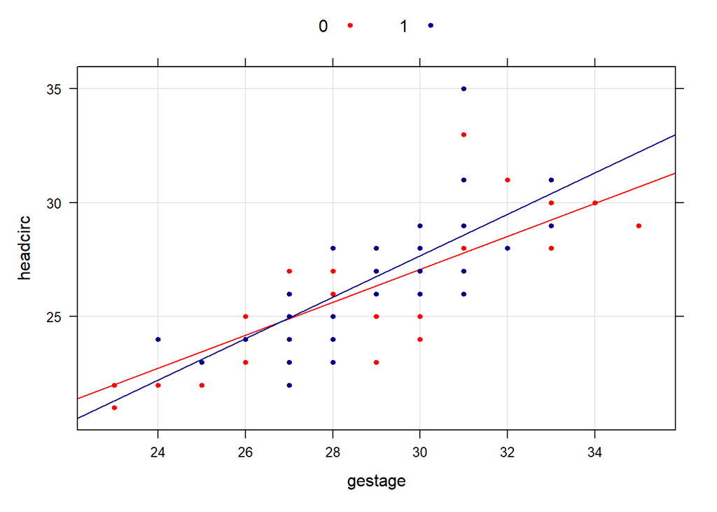

From the graph above we can see that the head circumference for both females and males increases as gestational age increases. However male head circumference tend to increase faster than female head circumference as gestational age increases.

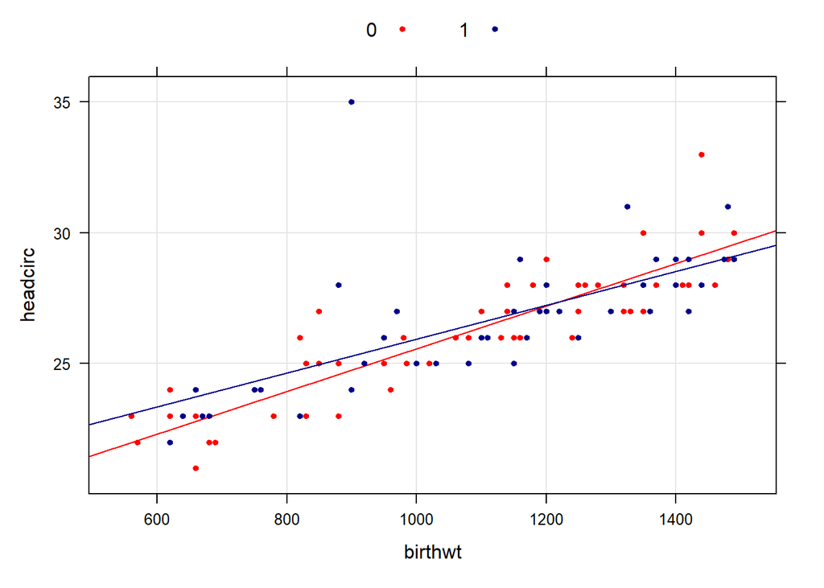

From the graph above we can see that the head circumference for both females and males increases as birth weight increases. However female head circumference tend to increase faster than male head circumference as birht weight increases.

## Checking the Distributions of the data

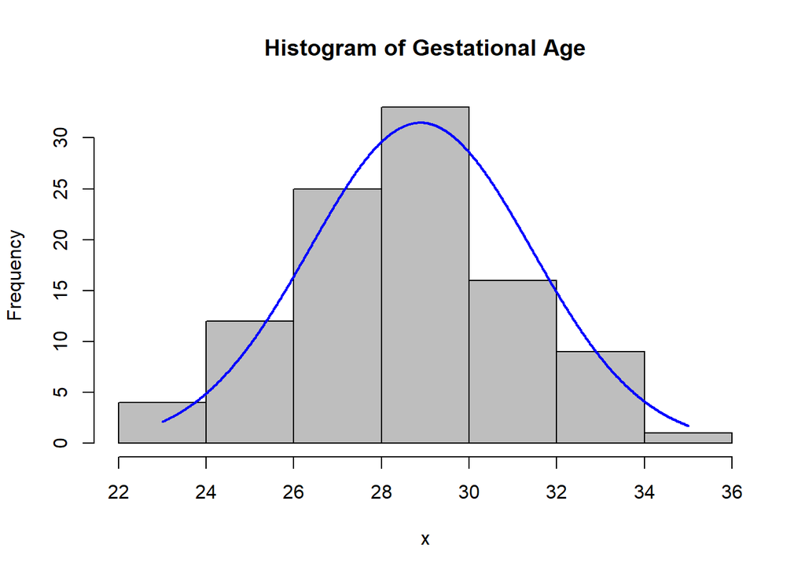

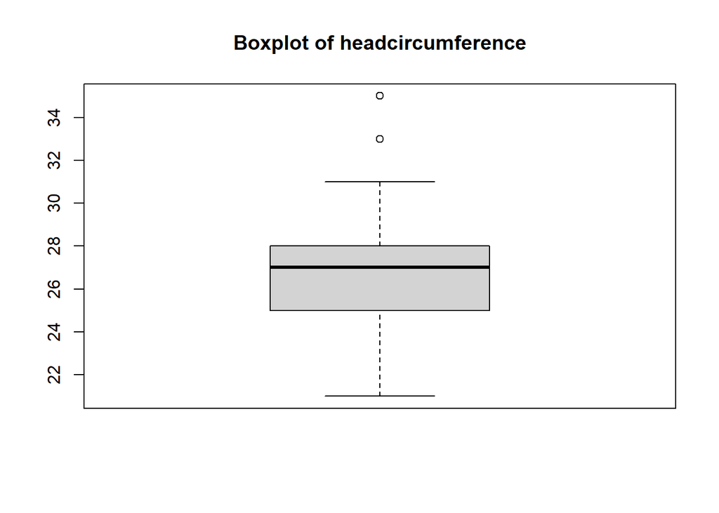

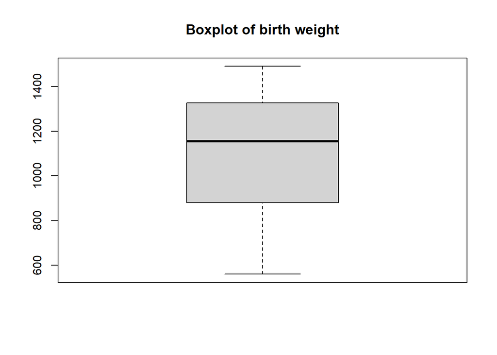

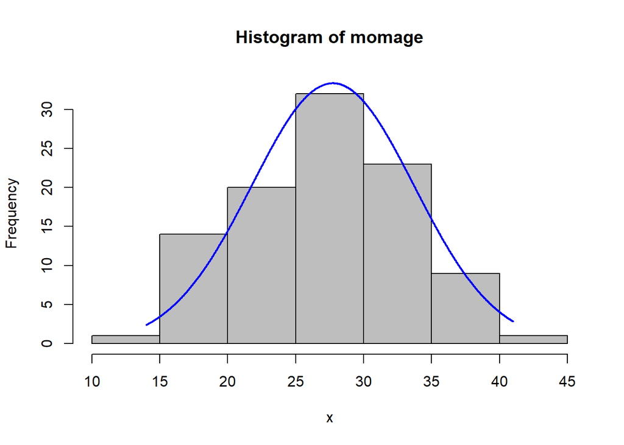

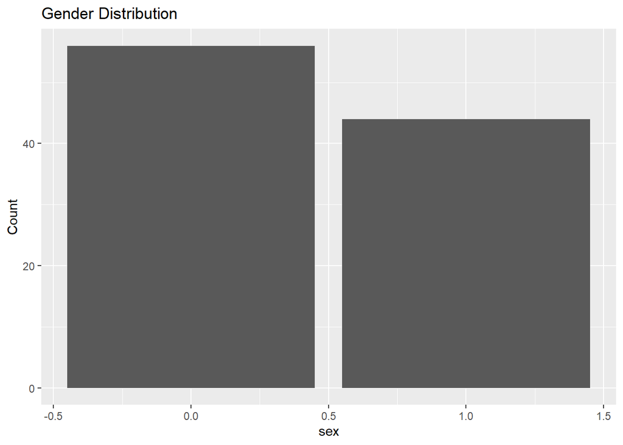

The graphs reveal that gestational age and momage approximately follow a normal distribution. However, the distribution of head circumference appears slightly skewed to the right, indicating a potential deviation from normality. Moreover, the presence of outliers in the data is evident. In contrast, the distribution of birth weight is slightly skewed to the left. Furthermore, the histogram illustrates a greater frequency of female babies (coded as 0) compared to male babies (coded as 1).

## COrrelation Matrix

[output not shown]

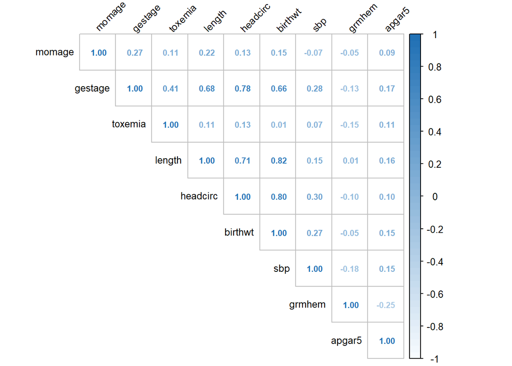

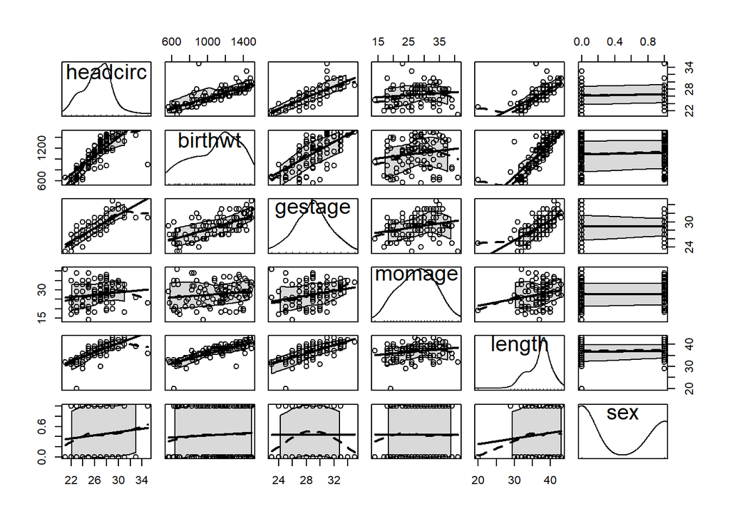

# REGRESSION MODELS

The next step in this project involves selecting the best model for the data. I will use AIC , LASSO , Cp and d R-Squared model selection criteria.

## Full regression model

```
Call:
lm(formula = headcirc ~ ., data = low_birth)

Residuals:
    Min      1Q  Median      3Q     Max
-1.8131 -0.6869 -0.0500  0.3018  7.8667

Coefficients:
              Estimate Std. Error t value Pr(>|t|)
(Intercept)  6.9545996  2.1908027   3.174  0.00206 **
momage      -0.0269360  0.0226181  -1.191  0.23682
gestage      0.5203399  0.0861789   6.038 3.44e-08 ***
toxemia     -0.5308288  0.3744738  -1.418  0.15978
length       0.0191553  0.0676638   0.283  0.77775
birthwt      0.0041124  0.0009096   4.521 1.87e-05 ***
sbp          0.0085803  0.0123204   0.696  0.48795
sex          0.2605805  0.2625683   0.992  0.32365
grmhem      -0.2016148  0.3832020  -0.526  0.60009
apgar5      -0.0626223  0.0556996  -1.124  0.26388
---
Signif. codes:  0 '***' 0.001 '**' 0.01 '*' 0.05 '.' 0.1 ' ' 1

Residual standard error: 1.276 on 90 degrees of freedom
Multiple R-squared:  0.7691,    Adjusted R-squared:  0.746
F-statistic: 33.31 on 9 and 90 DF,  p-value: < 2.2e-16
```

We can see that gestational age and birth weight are the significant (p-value < 05) variable in the model

## Reduced regression model

```
Call:
lm(formula = headcirc ~ gestage + birthwt, data = low_birth)

Residuals:
    Min      1Q  Median      3Q     Max
-2.0350 -0.7271 -0.0765  0.3472  8.5402

Coefficients:
             Estimate Std. Error t value Pr(>|t|)
(Intercept) 8.3080154  1.5789429   5.262 8.54e-07 ***
gestage     0.4487328  0.0672460   6.673 1.56e-09 ***
birthwt     0.0047123  0.0006312   7.466 3.60e-11 ***
---
Signif. codes:  0 '***' 0.001 '**' 0.01 '*' 0.05 '.' 0.1 ' ' 1

Residual standard error: 1.274 on 97 degrees of freedom
Multiple R-squared:  0.752, Adjusted R-squared:  0.7469
F-statistic: 147.1 on 2 and 97 DF,  p-value: < 2.2e-16
```

In this model , we remove all insignificant variables from the initial model.

## Reduced regression with Interactions

```
Call:
lm(formula = headcirc ~ gestage + birthwt + gestage * (as.factor(sex)) +
    birthwt * (as.factor(sex)), data = low_birth)

Residuals:
    Min      1Q  Median      3Q     Max
-2.0799 -0.6226 -0.0940  0.4105  7.6358

Coefficients:
                          Estimate Std. Error t value Pr(>|t|)
(Intercept)             11.1101375  1.8958315   5.860 6.80e-08 ***
gestage                  0.3021018  0.0848625   3.560 0.000584 ***
birthwt                  0.0059261  0.0008635   6.863 7.13e-10 ***
as.factor(sex)1         -7.8162725  3.3002668  -2.368 0.019914 *
gestage:as.factor(sex)1  0.3754163  0.1371646   2.737 0.007415 **
birthwt:as.factor(sex)1 -0.0025180  0.0012294  -2.048 0.043341 *
---
Signif. codes:  0 '***' 0.001 '**' 0.01 '*' 0.05 '.' 0.1 ' ' 1

Residual standard error: 1.238 on 94 degrees of freedom
Multiple R-squared:  0.7731,    Adjusted R-squared:  0.7611
F-statistic: 64.07 on 5 and 94 DF,  p-value: < 2.2e-16
```

Now, in this model we included interaction terms. We can see from initial plots that there was interaction between gestational age and sex and birth weight and sex. The adjusted R-squared increased which means that the interactions effect is significant in predicting the model.

## AIC Approach

```
Start:  AIC=53.32
headcirc ~ gestage + birthwt + gestage * (as.factor(sex)) + birthwt *
    (as.factor(sex)) + momage + length + sbp

                         Df Sum of Sq    RSS    AIC
- length                  1    0.0273 142.38 51.335
- sbp                     1    0.3284 142.68 51.546
- momage                  1    1.1466 143.50 52.118
<none>                                142.36 53.316
- birthwt:as.factor(sex)  1    5.4978 147.85 55.105
- gestage:as.factor(sex)  1    9.5914 151.95 57.836

Step:  AIC=51.34
headcirc ~ gestage + birthwt + as.factor(sex) + momage + sbp +
    gestage:as.factor(sex) + birthwt:as.factor(sex)

                         Df Sum of Sq    RSS    AIC
- sbp                     1    0.3050 142.69 49.549
- momage                  1    1.1268 143.51 50.123
<none>                                142.38 51.335
- birthwt:as.factor(sex)  1    5.4894 147.87 53.118
+ length                  1    0.0273 142.36 53.316
- gestage:as.factor(sex)  1    9.6135 152.00 55.869

Step:  AIC=49.55
headcirc ~ gestage + birthwt + as.factor(sex) + momage + gestage:as.factor(sex) +
    birthwt:as.factor(sex)

                         Df Sum of Sq    RSS    AIC
- momage                  1    1.3164 144.00 48.467
<none>                                142.69 49.549
+ sbp                     1    0.3050 142.38 51.335
- birthwt:as.factor(sex)  1    5.7003 148.39 51.466
+ length                  1    0.0040 142.68 51.546
- gestage:as.factor(sex)  1    9.9515 152.64 54.291

Step:  AIC=48.47
headcirc ~ gestage + birthwt + as.factor(sex) + gestage:as.factor(sex) +
    birthwt:as.factor(sex)

                         Df Sum of Sq    RSS    AIC
<none>                                144.00 48.467
+ momage                  1    1.3164 142.69 49.549
+ sbp                     1    0.4947 143.51 50.123
+ length                  1    0.0025 144.00 50.466
- birthwt:as.factor(sex)  1    6.4260 150.43 50.833
- gestage:as.factor(sex)  1   11.4760 155.48 54.135
```

```
Call:
lm(formula = headcirc ~ gestage + birthwt + as.factor(sex) +
    gestage:as.factor(sex) + birthwt:as.factor(sex), data = low_birth)

Residuals:
    Min      1Q  Median      3Q     Max
-2.0799 -0.6226 -0.0940  0.4105  7.6358

Coefficients:
                          Estimate Std. Error t value Pr(>|t|)
(Intercept)             11.1101375  1.8958315   5.860 6.80e-08 ***
gestage                  0.3021018  0.0848625   3.560 0.000584 ***
birthwt                  0.0059261  0.0008635   6.863 7.13e-10 ***
as.factor(sex)1         -7.8162725  3.3002668  -2.368 0.019914 *
gestage:as.factor(sex)1  0.3754163  0.1371646   2.737 0.007415 **
birthwt:as.factor(sex)1 -0.0025180  0.0012294  -2.048 0.043341 *
---
Signif. codes:  0 '***' 0.001 '**' 0.01 '*' 0.05 '.' 0.1 ' ' 1

Residual standard error: 1.238 on 94 degrees of freedom
Multiple R-squared:  0.7731,    Adjusted R-squared:  0.7611
F-statistic: 64.07 on 5 and 94 DF,  p-value: < 2.2e-16
```

In this model, the AIC starts at 53.32, the model then drop one variable each time until it has the lowest AIC 48.47 Therefore we have gestage, birthweight and the interactions of gestage , birthweight and sex as the significant variables. The adjusted R-Squared increased in this model to 0.7611

## LASSO Model

```
10 x 1 sparse Matrix of class "dgCMatrix"
                      s1
(Intercept) 12.976461800
momage       .
gestage      0.329674713
toxemia      .
length       .
birthwt      0.003593972
sbp          .
sex          .
grmhem       .
apgar5       .
```

In the LASSO model, We can also see that the insignificant variables are been dropped off. Hence we have birth weight and gest age as the significant variables.

## Model Selection by CP

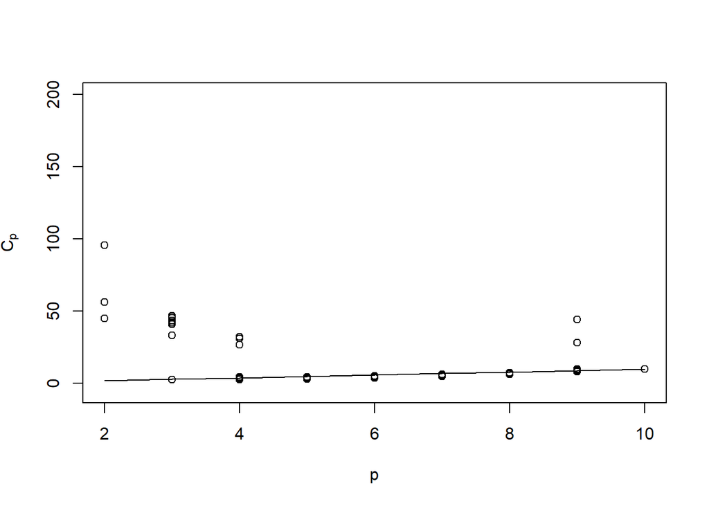

```
Call:
lm(formula = y ~ foo)

Residuals:
    Min      1Q  Median      3Q     Max
-2.0350 -0.7271 -0.0765  0.3472  8.5402

Coefficients:
             Estimate Std. Error t value Pr(>|t|)
(Intercept) 8.3080154  1.5789429   5.262 8.54e-07 ***
foogestage  0.4487328  0.0672460   6.673 1.56e-09 ***
foobirthwt  0.0047123  0.0006312   7.466 3.60e-11 ***
---
Signif. codes:  0 '***' 0.001 '**' 0.01 '*' 0.05 '.' 0.1 ' ' 1

Residual standard error: 1.274 on 97 degrees of freedom
Multiple R-squared:  0.752, Adjusted R-squared:  0.7469
F-statistic: 147.1 on 2 and 97 DF,  p-value: < 2.2e-16
```

In the Cp model, We can also see that the insignificant variables are been dropped off. Hence we have birthweight and gestage as the significant variables.

## Model Selection by R-Squared

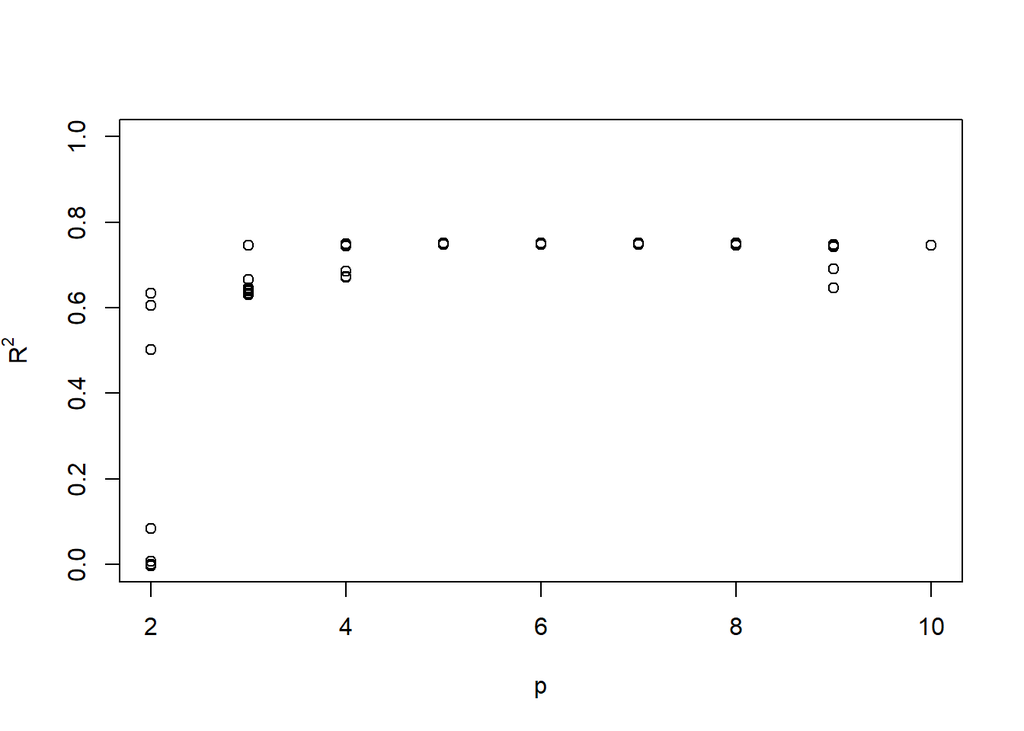

# COMPARING REGRESSION MODELS PERFORMANCE

## Metrics for model 1 (model with all variables)

| adj.r.squared | sigma | AIC | BIC | p.value |
| --- | --- | --- | --- | --- |
| 0.7460233 | 1.276088 | 344.0115 | 372.6684 | 5.733572e-25 |

## Metrics for model2 (model with all significant variables)

| adj.r.squared | sigma | AIC | BIC | p.value |
| --- | --- | --- | --- | --- |
| 0.7468784 | 1.273938 | 337.1644 | 347.5851 | 4.281424e-30 |

## Metrics for model 3(model with interactions)

| adj.r.squared | sigma | AIC | BIC | p.value |
| --- | --- | --- | --- | --- |
| 0.7610645 | 1.237725 | 334.2551 | 352.4913 | 9.105417e-29 |

## Metrics for model 4(model with interactions)

| adj.r.squared | sigma | AIC | BIC | p.value |
| --- | --- | --- | --- | --- |
| 0.7610645 | 1.237725 | 334.2551 | 352.4913 | 9.105417e-29 |

| adj.r.squared | sigma | AIC | BIC | p.value |
| --- | --- | --- | --- | --- |
| 0.7468784 | 1.273938 | 337.1644 | 347.5851 | 4.281424e-30 |

## Model interpretation

```r
summary(low.lm3)
```

```
Call:
lm(formula = headcirc ~ gestage + birthwt + gestage * (as.factor(sex)) +
    birthwt * (as.factor(sex)), data = low_birth)

Residuals:
    Min      1Q  Median      3Q     Max
-2.0799 -0.6226 -0.0940  0.4105  7.6358

Coefficients:
                          Estimate Std. Error t value Pr(>|t|)
(Intercept)             11.1101375  1.8958315   5.860 6.80e-08 ***
gestage                  0.3021018  0.0848625   3.560 0.000584 ***
birthwt                  0.0059261  0.0008635   6.863 7.13e-10 ***
as.factor(sex)1         -7.8162725  3.3002668  -2.368 0.019914 *
gestage:as.factor(sex)1  0.3754163  0.1371646   2.737 0.007415 **
birthwt:as.factor(sex)1 -0.0025180  0.0012294  -2.048 0.043341 *
---
Signif. codes:  0 '***' 0.001 '**' 0.01 '*' 0.05 '.' 0.1 ' ' 1

Residual standard error: 1.238 on 94 degrees of freedom
Multiple R-squared:  0.7731,    Adjusted R-squared:  0.7611
F-statistic: 64.07 on 5 and 94 DF,  p-value: < 2.2e-16
```

This is our final model. From the coefficients, we can form our model as follows:

$Head Circumference= 11.1101375+0.3021018(Gestage) + 0.0059261(birthweight) -7.8162725(sex1) + 0.3754163(sex1*gestage)-0.0025180(sex1*birthweight)$

## Coefficients

The intercept is $11.1101375$cm. This means that, on average head circumference will be $11.1101375$cm when all other variables are zero.

The coefficient of gestage shows that for any additional week in gestational age , the average head circumference will increases by $0.3021018$cm holding birthweight and sex constant.

The coefficient of birth weight shows that, for any additional gram increase in birth weight, hea circumference will increase by $0.0059261$cm holding gestational age and sex constant.

The coefficient of sex shows that, the average head circumference for male infants is $7.8162725$cm lesser than for female when gestational age and birthweight is zero.

This coefficient value cannot be relied upon since it not meaningful.

The coefficient of sex1*gestage shows that, for any additional week in gestational age, the average increase in head circumference for male infants is $0.3754163$ higher for males than for female holding all other variables in the model constant.

The coefficient of sex1*birthweight shows that, for any additional gram in birth weight , the average increase in head circumference for male infants is $0.0025180$ lower for males than for female holding all other variables in the model constant.

## Overall F-statistics

The null hypothesis states that there is no relationship between the dependent variable and the independent variable(s) and the alternative hypothesis is that there exists at least one $\beta_i>0$. In this study, the *F-statistics* is 64.07 with degrees of freedom on 5 and 94. The p-value < 2.2e-16 which is less than $\alpha=0.05$. This means that there is at least one significant relationship between the independent variables and dependent variables in the model.

# Iindividual T-Test for the coefficients ($\beta_i$)

## Gesage ($\beta_1$)

The null hypothesis states that,the coefficient for the gestage in the regression model is not significantly different from zero and the alternative hypothesis is that the coefficient for the gestage in the regression model is significantly different from zero. In this study, the T-statistics is 3.560.The p-value is 0.000584 which is less than $\alpha=0.05$. We reject the null hypothesis and conclude that the coefficient for the gestate variable is significantly different from zero, indicating that, gestational age is a significant and good predictor variable for the head circumference even with birth weight ,sex, interactions of sex with birth weight and gestational age in the data.

## birthweight ($\beta_2$)

The null hypothesis states that , the coefficient for the birthweight in the regression model is not significantly different from zero and the alternative hypothesis is that the coefficient for the birthweight in the regression model is significantly different from zero. In this study, the T-statistics is 6.863.The p-value is 7.13e-10 which is less than $\alpha=0.05$. We reject the null hypothesis and conclude that the coefficient for the birthweight variable is significantly different from zero, indicating that, birth weight is a significant and good predictor variable for the head circumference even with gestage,sex,interactions of sex with birth weight and gestational age in the data.

## sex ($\beta_3$)

The null hypothesis states that , the coefficient for sex in the regression model is not significantly different from zero and the alternative hypothesis is that the coefficient for the sex in the regression model issignificantly different from zero. In this study, the T-statistics is -2.368 .The p-value is 0.019914 which is less than $\alpha=0.05$. We reject the null hypothesis and conclude that the coefficient for the sex variable is significantly different from zero, indicating that, sex is a significant and good predictor variable for the head circumference even with gestage ,gestational age,interactions of sex with birth weight and gestational age in the data.

## Interaction of sex and gestage ($\beta_4$)

The null hypothesis states that , the coefficient for the ($\beta_4$) is not significantly different from zero and the alternative hypothesis is that the coefficient for the ($\beta_4$) in the regression model is significantly different from zero. In this study, the T-statistics is 2.737.The p-value is 0.007415 which is less than $\alpha=0.05$ = 0.05. We reject the null hypothesis and conclude that the coefficient for the interaction of sex and gestage variable is significantly different from zero, indicating that, the interaction of sex and gestage is a significant and good predictor variable for the head circumference even with gestage,gestational age and interactions of sex with birth weight.

## Interaction of sex and birth weight($\beta_5$)

# MODEL DIAGNOSTICS

In this part we check to see whether all residual assumptions of linear regression models have been achieved. We will check for normality, linearity , equal variance , independence , and colinearity of residuals.

## External Residual

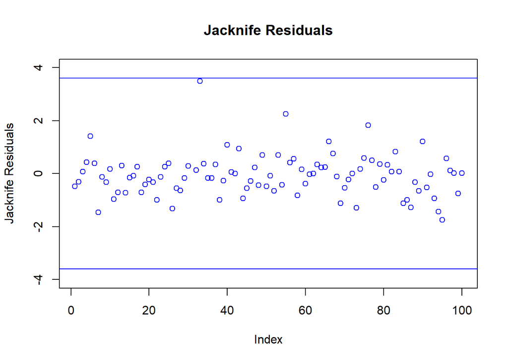

**Output the largest residual**

```
      31
8.810603
```

The largest residual value is 8.810603

## Leverage

[figure not shown]

```
integer(0)
```

## Influential

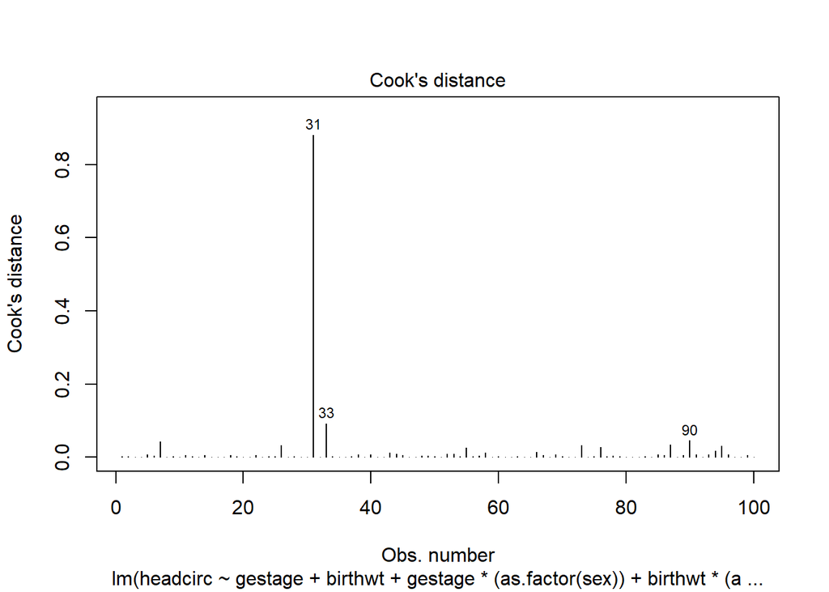

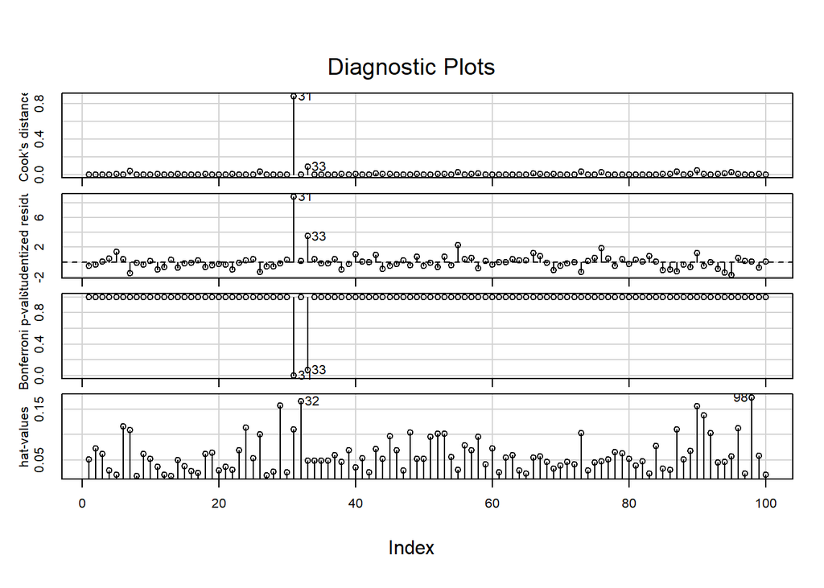

```
Potentially influential observations of
     lm(formula = headcirc ~ gestage + birthwt + gestage * (as.factor(sex)) +      birthwt * (as.factor(sex)), data = low_birth) :

   dfb.1_ dfb.gstg dfb.brth dfb.a.() dfb.g:.( dfb.b:.( dffit   cov.r   cook.d
6   0.00   0.00     0.00     0.08    -0.05    -0.03     0.14    1.20_*  0.00
24  0.00   0.00     0.00    -0.06     0.05     0.01     0.09    1.20_*  0.00
29  0.03  -0.05     0.07    -0.02     0.03    -0.05    -0.07    1.26_*  0.00
31  0.00   0.00     0.00    -1.57_*   1.96_*  -1.69_*   3.10_*  0.03_*  0.88
32 -0.03   0.05    -0.06     0.02    -0.03     0.04     0.06    1.28_*  0.00
33 -0.06  -0.12     0.51     0.03     0.07    -0.36     0.79_*  0.53_*  0.09
55  0.14  -0.02    -0.16    -0.08     0.01     0.12     0.40    0.80_*  0.03
91  0.00   0.00     0.00     0.15    -0.15     0.07    -0.21    1.22_*  0.01
98  0.00   0.00     0.00    -0.01     0.01    -0.01     0.01    1.29_*  0.00
   hat
6   0.12
24  0.11
29  0.16
31  0.11
32  0.17
33  0.05
55  0.03
91  0.14
98  0.17
```

The table gives the points that are influential in the dataset

**Bonferroni p-values for testing outliner**

```
   rstudent unadjusted p-value Bonferroni p
31 8.810603         6.7066e-14   6.7066e-12
```

With a very small Bonferroni p- value which is less than 0.05, we can conclude that the effect of outliers in the data is significant.

## Homoscedasticity (Equal Variance Assumption)

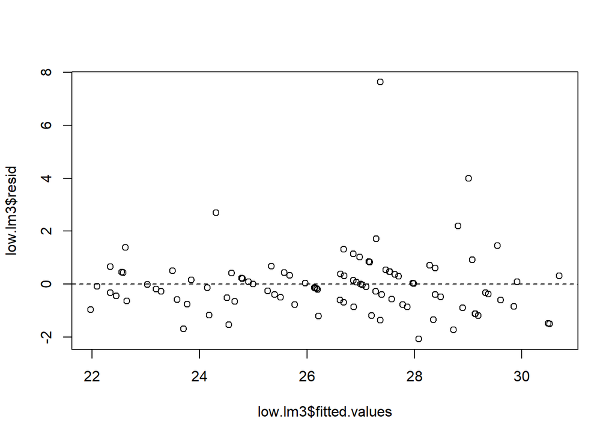

```
    studentized Breusch-Pagan test

data:  low.lm3
BP = 10.676, df = 5, p-value = 0.05819
```

With a large Breusch Pagan p- value which is greater than 0.05, we can conclude that the variances are constant , hence Homoscedasticity is satisfied

## Linearity

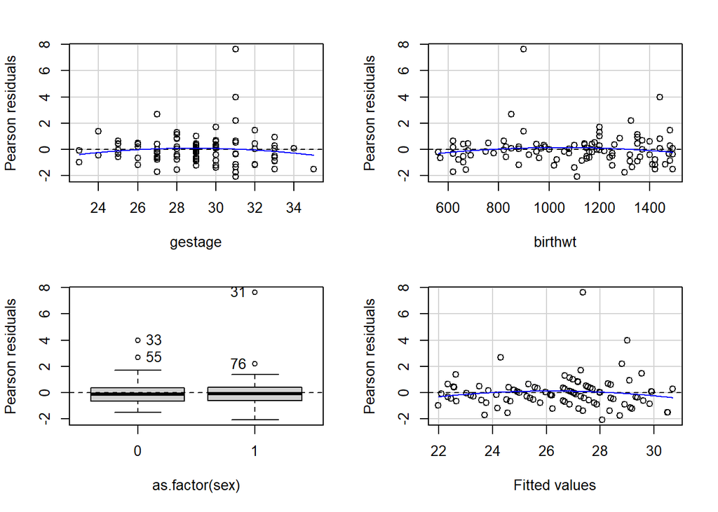

```
               Test stat Pr(>|Test stat|)
gestage          -0.9498           0.3447
birthwt          -1.0410           0.3006
as.factor(sex)
Tukey test       -1.1015           0.2707
```

From the plots and the test , we can conclude that the residuals are somewhat linear.

## Normality Test

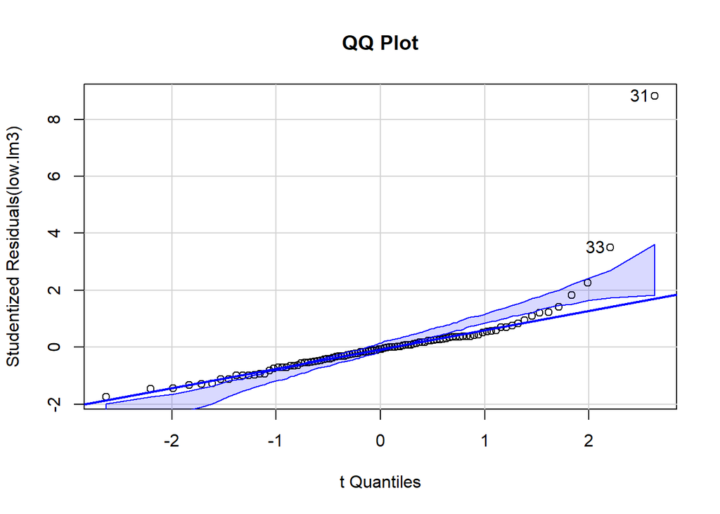

```
[1] 31 33
```

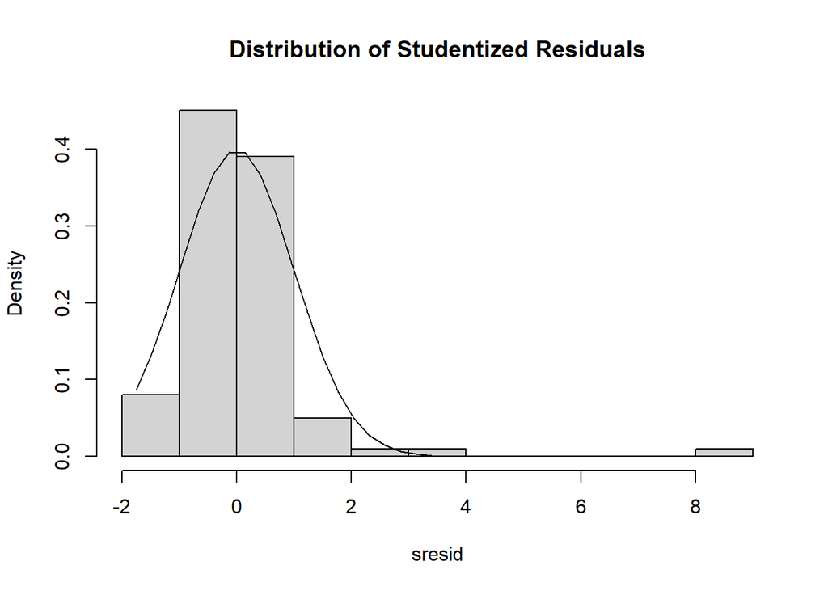

```
    Shapiro-Wilk normality test

data:  residuals(low.lm3)
W = 0.7808, p-value = 6.639e-11
```

From the normal plots and the shapiro normality test , we can say the residuals are not normally distributed.

## variance inflation factor (Multicolinearity)

```
there are higher-order terms (interactions) in this model
consider setting type = 'predictor'; see ?vif
```

```
               gestage                birthwt         as.factor(sex)
              2.988805               3.512528             175.182450
gestage:as.factor(sex) birthwt:as.factor(sex)
            255.251407              33.116183
```

```
there are higher-order terms (interactions) in this model
consider setting type = 'predictor'; see ?vif
```

```
               gestage                birthwt         as.factor(sex)
                 FALSE                  FALSE                   TRUE
gestage:as.factor(sex) birthwt:as.factor(sex)
                  TRUE                   TRUE
```

with large variance inflation factor, we can conclude that there is colinearity in the data.

```
 lag Autocorrelation D-W Statistic p-value
   1       0.1264567      1.744769   0.164
 Alternative hypothesis: rho != 0
```

[figure not shown]

The residuals are spread out around zero, Hence the residuals are independent.The p-value for durbinWatsonTest confirms this.

It is important to note that the model does not meet all the assumptions of multiple linear regression.This indicates that the results may not be entirely reliable and should be interpreted with caution. Further research is needed to validate these findings and to identify other factors that may be influencing head circumference in low birth weight infants.